# Reporting_LongVision

## Historische Daten und Performer Mergen

### 1. Zeitstemp angleichen

Zeit stempel wird an Dukascopy angeglichen (GTM).Laut MyFXbook ist LongVision GTM+2. Hier werden Random Entries aus der Preformer Data genommen (Nur EURUSD trades) und mit Histroy verglichen.

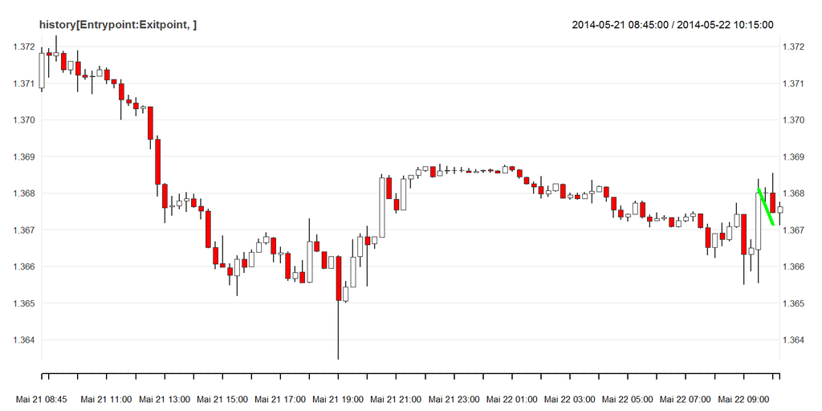

```
##   Entrypoint Exitpoint OpenPrice ClosePrice                Open
## 1      48504     48606   1.36811    1.36715 2014-05-22 09:45:00
##                 Close Action
## 1 2014-05-22 10:15:00    Buy
```

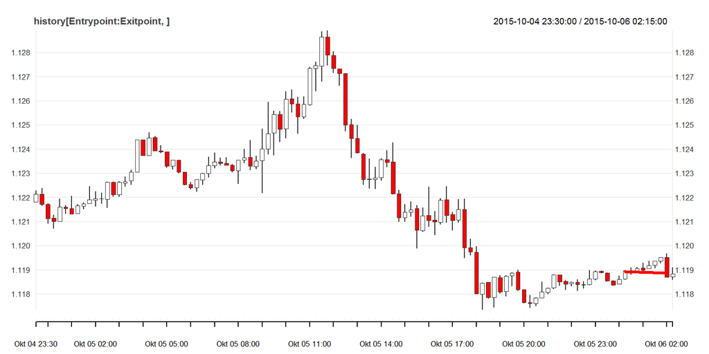

```
##   Entrypoint Exitpoint OpenPrice ClosePrice                Open
## 1      96655     96762   1.11894    1.11888 2015-10-06 00:28:00
##                 Close Action
## 1 2015-10-06 02:15:00   Sell
```

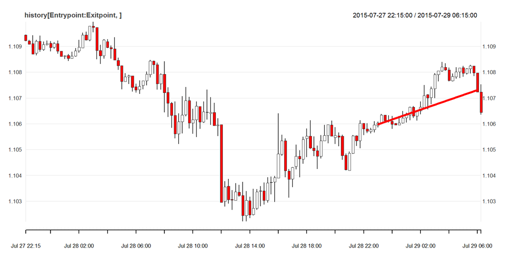

```
##   Entrypoint Exitpoint OpenPrice ClosePrice                Open
## 1      90026     90154   1.10599    1.10731 2015-07-28 23:15:00
##                 Close Action
## 1 2015-07-29 06:15:00   Sell
```

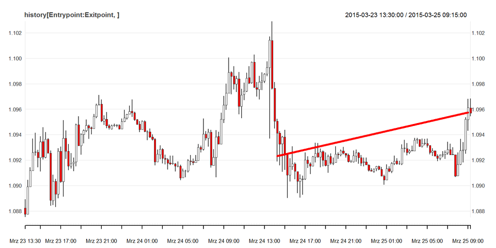

```
##   Entrypoint Exitpoint OpenPrice ClosePrice                Open
## 1      77903     78078   1.09233    1.09575 2015-03-24 14:25:00
##                 Close Action
## 1 2015-03-25 09:08:00   Sell
```

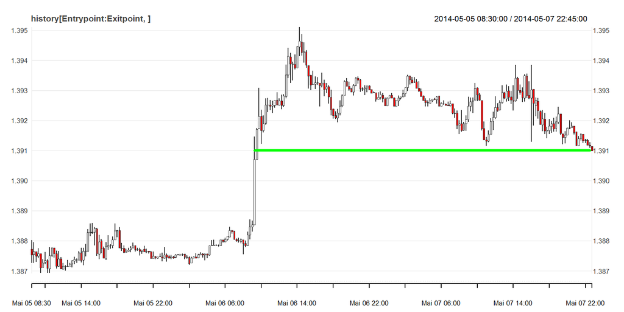

```
##   Entrypoint Exitpoint OpenPrice ClosePrice                Open
## 1      46967     47216   1.39102    1.39102 2014-05-06 09:25:00
##                 Close Action
## 1 2014-05-07 22:37:00    Buy
```

```r
#Pick Random Entry

##Test Parameter:
Symbol<-"EURUSD"

data.Test<- data.History[[Symbol]]
data.Performer.clean.Test<- data.Performer.clean[data.Performer.clean$Symbol==Symbol,]

TF<-"M15"
set.seed(0)
for(n in 1:5)
  {
    TimeSyncVis(data.Test[[TF]],data.Performer.clean,Symbol)
  }
```

Püfen wieviele Entries zwischen High und Low Liegen in abhängigkeit von TimeFrame:

```r
#EURUSD
##M5
checkSync(data.Performer.clean.Test,data.Test[["M5"]])
```

```
## [1] "Sync: 0.92"
## [1] "Sum of unSynced: 359"
```

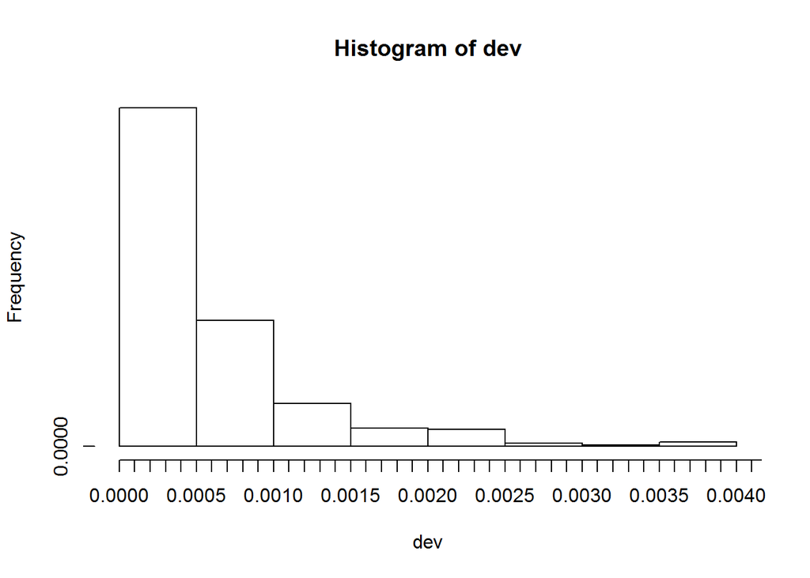

```r
##M15
checkSync(data.Performer.clean.Test,data.Test[["M15"]])
```

```
## [1] "Sync: 0.96"
## [1] "Sum of unSynced: 163"
```

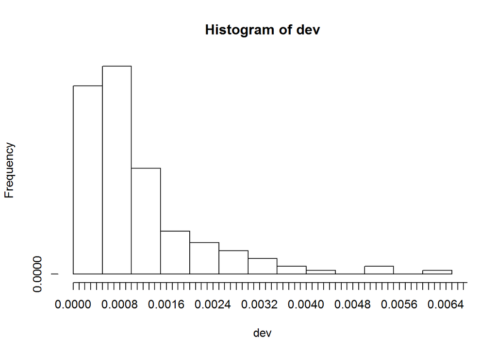

**Nach dieser Analyse Sieht es nicht so aus als müssten man das anpassen. Oben beim Cleaning wurden die Zeiten Convetiert ohne Timezone anzugeben, also wurde da auch nichts geändert.**

### 2. Exploratory Analysis

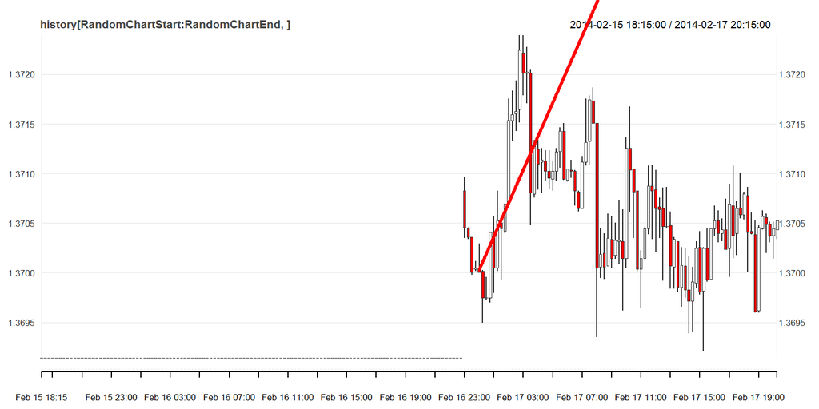

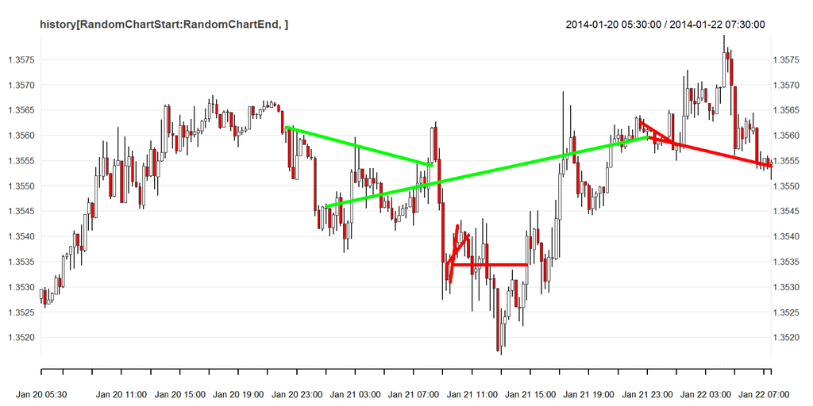

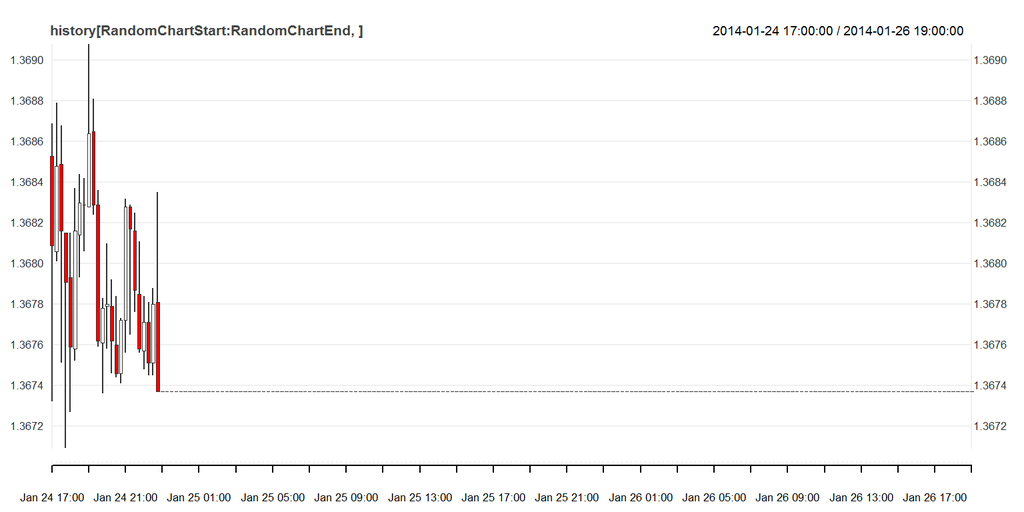

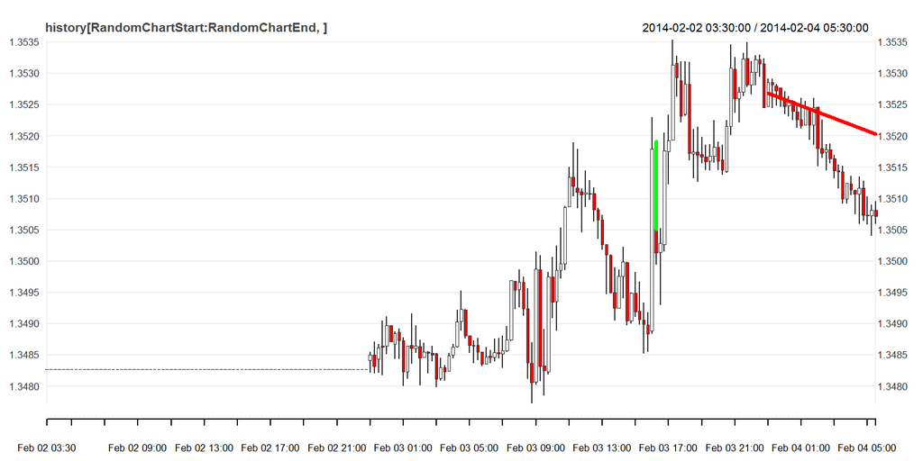

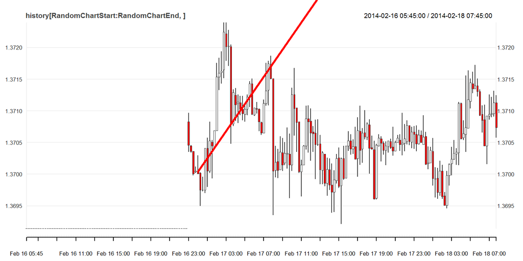

```r
set.seed(0)
TF<-"M15"
for (n in 1:5)
{
      RandomePAHistory(data.Test[[TF]],data.Performer.clean, Symbol,200)
}
```

Aktuell kein muster erkennbar bis auf eine Flag-Strategie. In Strategie beschreibung vom Performer ist es eine Summe vo Strategien die auf dem Konto Laufen.

### 3. Performance Data mit Price muster versehen.

In diesem abschnitt wird die daten “data.Performer.Clean” mit eine Preis muster der zur Auswertung später benötigt wird. der Preis musster besteht aus x abgeschlossene Kerzen aus unterschiedliche TFs.

Schreibt File LongVision_AboslutPrice.csv mit xBar Pattern für TFs (M5,M15,H1,H4,D1):

```r
#Folgende Instrumente werden benötigt:
summary(data.Performer.clean$Symbol)
```

```
## AUDUSD EURGBP EURJPY EURUSD GBPCHF GBPUSD USDCAD USDCHF USDJPY
##    321    125     10   4535     78   4706    255    209   2344
```

```r
#File Path:
SaveFileDirectory<-"./Files/LongVision/"
SaveFileName<-"LongVision_AbsolutPrices.csv"
FilePath<-paste(SaveFileDirectory,SaveFileName,sep="")

#Parameter:
Bars.Lookback<-5
Symbol<-c("EURUSD","GBPUSD","USDJPY","AUDUSD")
Timeframe<-c("M5","M15", "H1","H4","D1")

if(!file.exists(FilePath))
{
#get Pattern
data.Performer.pattern.AbsolutPrices<- Pattern.CreateData(data.Performer.clean,data.History,Symbol,Timeframe,Norm=FALSE)

#Write File
write.csv(data.Performer.pattern.AbsolutPrices,file=FilePath)
}else
{
  data.Performer.pattern.AbsolutPrices<- read.csv(FilePath,stringsAsFactors=TRUE)
}
head(data.Performer.pattern.AbsolutPrices,5)
```

```
##    X                open               close Symbol Action Lots      SL
## 1  9 2016-09-08 23:54:00 2016-09-09 08:46:00 EURUSD   Sell 0.03 1.12942
## 2 11 2016-09-08 23:15:00 2016-09-09 08:45:00 EURUSD   Sell 0.08 1.13014
## 3 19 2016-09-08 16:15:00 2016-09-09 02:20:00 EURUSD   Sell 0.12 1.12741
## 4 21 2016-09-08 16:30:00 2016-09-09 02:20:00 EURUSD   Sell 0.12 1.12737
## 5 23 2016-09-08 23:09:00 2016-09-09 02:02:00 EURUSD   Sell 0.10 1.13211
##        TP Open.Price Close.Price Commission Swap Pips Profit  Gain
## 1 1.11652    1.12650     1.12708          0 0.04 -5.8  -1.50 -0.01
## 2 1.12424    1.12614     1.12690          0 0.11 -7.6  -5.29 -0.04
## 3 1.11594    1.12741     1.12743          0 0.16 -0.2  -0.05  0.00
## 4 1.11587    1.12737     1.12743          0 0.16 -0.6  -0.48  0.00
## 5 1.12561    1.12608     1.12629          0 0.13 -2.1  -1.73 -0.01
##   Duration..DD.HH.MM.SS. Profitable... Profitable.time.duration. Drawdown
## 1            00:08:52:07             0                        0s        0
## 2            00:09:29:42             0                        0s        0
```

[output cut: 153 more lines]

Schreibt File LongVision_ScaledPrice.csv mit xBar Pattern für TFs (M5,M15,H1,H4,D1):

```r
#File Path:
SaveFileName<-"LongVision_ScaledPrices.csv"
FilePath<-paste(SaveFileDirectory,SaveFileName,sep="")

if(!file.exists(FilePath))
{
  #get Pattern
  data.Performer.pattern.ScaledPrice<- Pattern.CreateData(data.Performer.clean,data.History,Symbol,Timeframe,Norm=TRUE)

  #Write File
  write.csv(data.Performer.pattern.ScaledPrice,file=FilePath)
}else
{
  data.Performer.pattern.ScaledPrice<- read.csv(FilePath,stringsAsFactors=TRUE)
}
head(data.Performer.pattern.ScaledPrice,5)
```

```
##    X                open               close Symbol Action Lots      SL
## 1  9 2016-09-08 23:54:00 2016-09-09 08:46:00 EURUSD   Sell 0.03 1.12942
## 2 11 2016-09-08 23:15:00 2016-09-09 08:45:00 EURUSD   Sell 0.08 1.13014
## 3 19 2016-09-08 16:15:00 2016-09-09 02:20:00 EURUSD   Sell 0.12 1.12741
## 4 21 2016-09-08 16:30:00 2016-09-09 02:20:00 EURUSD   Sell 0.12 1.12737
## 5 23 2016-09-08 23:09:00 2016-09-09 02:02:00 EURUSD   Sell 0.10 1.13211
##        TP Open.Price Close.Price Commission Swap Pips Profit  Gain
## 1 1.11652    1.12650     1.12708          0 0.04 -5.8  -1.50 -0.01
## 2 1.12424    1.12614     1.12690          0 0.11 -7.6  -5.29 -0.04
## 3 1.11594    1.12741     1.12743          0 0.16 -0.2  -0.05  0.00
## 4 1.11587    1.12737     1.12743          0 0.16 -0.6  -0.48  0.00
## 5 1.12561    1.12608     1.12629          0 0.13 -2.1  -1.73 -0.01
##   Duration..DD.HH.MM.SS. Profitable... Profitable.time.duration. Drawdown
## 1            00:08:52:07             0                        0s        0
## 2            00:09:29:42             0                        0s        0
```

[output cut: 93 more lines]

## 4. Create Test Data

```r
SaveFileName<-"LongVision_PatternEntries.csv"
FilePath<-paste(SaveFileDirectory,SaveFileName,sep="")

if(!file.exists(FilePath))
{
  ColumnsCleanData<-ncol(data.Performer.clean)
  data.Pattern.Entries<-Pattern.Entries(ColumnsCleanData, data.Performer.pattern.ScaledPrice)

  #Write File
  write.csv(data.Pattern.Entries,file=FilePath)
}else
{
  data.Pattern.Entries<- read.csv(FilePath,stringsAsFactors=TRUE)
}
head(data.Pattern.Entries,5)
```

```
##   X                open Action Hour Min   M5.High      M5.Low   M5.Close
## 1 1 2016-09-08 23:54:00   Sell   23  54 0.0000000 -0.36144578 -0.1807229
## 2 2 2016-09-08 23:15:00   Sell   23  15 0.3370787 -1.29213483 -0.8426966
## 3 3 2016-09-08 16:15:00   Sell   16  15 0.1963993 -0.28641571 -0.2045827
## 4 4 2016-09-08 16:30:00   Sell   16  30 1.5577342 -0.03267974  0.9150327
## 5 5 2016-09-08 23:09:00   Sell   23   9 0.1190476 -0.65476190 -0.5952381
##    M5.High.1   M5.Low.1 M5.Close.1   M5.High.2   M5.Low.2 M5.Close.2
## 1 -0.1807229 -1.2650602 -1.0240964 -0.06024096 -1.3253012 -0.3614458
## 2 -0.4494382 -1.3483146 -0.4494382  0.05617978 -0.5617978 -0.5056180
## 3  1.3911620 -0.2618658  1.3911620  1.76759411  1.0474632  1.4648118
## 4  2.1677560  0.9041394  1.2527233  2.14596950  1.2418301  1.7429194
## 5 -0.5952381 -1.4880952 -1.3095238 -1.01190476 -2.7380952 -2.2619048
##    M5.High.3   M5.Low.3  M5.Close.3   M5.High.4   M5.Low.4 M5.Close.4
## 1  0.1807229 -0.3614458 -0.06024096  0.06024096 -1.6867470  -1.084337
## 2 -0.5056180 -1.3483146 -1.29213483 -0.84269663 -1.8539326  -1.685393
```

[output cut: 69 more lines]